# 마케팅 예산 및 매출 선형 회귀분석

**데이터셋 출처**

https://www.kaggle.com/datasets/singhnavjot2062001/product-advertising-data

```python
import pandas as pd
```

```python
pd.options.display.float_format = '{:.2f}'.format
```

```python
data = pd.read_csv('Advertising_data.csv')
```

```python
data.info()
```

```
<class 'pandas.core.frame.DataFrame'>
RangeIndex: 300 entries, 0 to 299
Data columns (total 7 columns):
 #   Column                Non-Null Count  Dtype
---  ------                --------------  -----
 0   TV                    300 non-null    float64
 1   Billboards            300 non-null    float64
 2   Google_Ads            300 non-null    float64
 3   Social_Media          300 non-null    float64
 4   Influencer_Marketing  300 non-null    float64
 5   Affiliate_Marketing   300 non-null    float64
 6   Product_Sold          300 non-null    float64
dtypes: float64(7)
memory usage: 16.5 KB
```

# 컬럼 설명

- TV: TV방송 비용
- Billboards : 빌보드 마케팅 비용
- Google_Ads : 구글 광고 비용
- Social_Media : 소셜미디어 비용
- Influencer_Marketing : 인플루언서 마케팅 비용
- Affiliate_Marketing : 제휴 마케팅 비용
- Product_Sold : 상품판매액

각 데이터는 월별 비용/매출에 관련된 데이터라고 가정하고, Product_Sold 컬럼은 다음달 매출액 데이터라고 가정한다.

```python
data.head()
```

|  | TV | Billboards | Google_Ads | Social_Media | Influencer_Marketing | Affiliate_Marketing | Product_Sold |
| --- | --- | --- | --- | --- | --- | --- | --- |
| 0 | 281.42 | 538.80 | 123.94 | 349.30 | 242.77 | 910.10 | 7164.00 |
| 1 | 702.97 | 296.53 | 558.13 | 180.55 | 781.06 | 132.43 | 5055.00 |
| 2 | 313.14 | 295.94 | 642.96 | 505.71 | 438.91 | 464.23 | 6154.00 |
| 3 | 898.52 | 61.27 | 548.73 | 240.93 | 278.96 | 432.27 | 5480.00 |
| 4 | 766.52 | 550.72 | 651.91 | 666.33 | 396.33 | 841.93 | 9669.00 |

# Exploratory Data Analysis

- Y :(종속변수/반응변수) Product_Sold
- X :(독립변수/설명변수) TV ~ Affiliate_Marketing

라고 할 때, 채널별 마케팅 비용과 상품판매액간의 관계를 탐색해보고자 선형회귀모델을 사용하고자 함.

선형회귀모델을 사용하기 위해 아래의 가정을 만족해야함

1. 반응변수와 설명변수 간의 비선형관계인지 / 선형관계인지 (선형성)
2. 오차항들간의 상관성은 있는지 없는지 (계열상관성)
3. 오차항의 기댓값은 0
4. 오차항의 분산은 모든 관찰치에서 일정할 것 (등분산성) (이분산성X)
5. 오차항과 독립변수가 상관관계가 없을 것 (내생성)
6. 다중공선성 확인 (다중회귀모형)
7. 이상치 확인 및 제거
8. 레버리지가 높은 관측치 확인 및 제거

https://blog.naver.com/yonxman/220950614789

```python
# data.columns
```

```python
X = data[['TV', 'Billboards', 'Google_Ads', 'Social_Media','Influencer_Marketing', 'Affiliate_Marketing']]
y = data['Product_Sold']

from sklearn.linear_model import LinearRegression
mlr_model = LinearRegression()
mlr_model.fit(X,  y)

data['Sold_predict'] = mlr_model.predict(X)
data['Residual'] = (data['Product_Sold'] - data['Sold_predict'])
print('MSE: ', np.mean(data['Residual']**2)) # MSE
```

```
MSE:  104.84572210702675
```

```python
print('R^2: ', mlr_model.score(X,y))
```

```
R^2:  0.9999637541828039
```

MSE가 104, $R^2$ 가 99.9%

```python
mlr_model.coef_
```

```
array([2.00111048, 2.99803879, 1.49974348, 2.50002106, 1.19984407,
       3.99891569])
```

```python
mlr_model.intercept_
```

```
0.08869523475459573
```

```python
data.columns
```

[output not shown]

```python
b0 = round(mlr_model.intercept_, 2)
b1 = round(mlr_model.coef_[0], 2)
b2 = round(mlr_model.coef_[1], 2)
b3 = round(mlr_model.coef_[2], 2)
b4 = round(mlr_model.coef_[3], 2)
b5 = round(mlr_model.coef_[4], 2)
b6 = round(mlr_model.coef_[5], 2)

print(f'회귀식 Product_Sold ~ {b0} + {b1} TV + {b2} Billboards + {b3} Google_Ads + {b4} Social_Media + {b5} Influencer_Marketing + {b6} Affiliate_Marketing')
```

```
회귀식 Product_Sold ~ 0.09 + 2.0 TV + 3.0 Billboards + 1.5 Google_Ads + 2.5 Social_Media + 1.2 Influencer_Marketing + 4.0 Affiliate_Marketing
```

### 1. 반응변수와 설명변수 간의 비선형 관계인지 확인

-> 잔차그래프로 확인 만약 패턴이 존재한다면, 선형모델에 어떤 문제가 있을 수 있다.

잔차그래프에서 인지할만한 패턴이 존재하지 않는다.

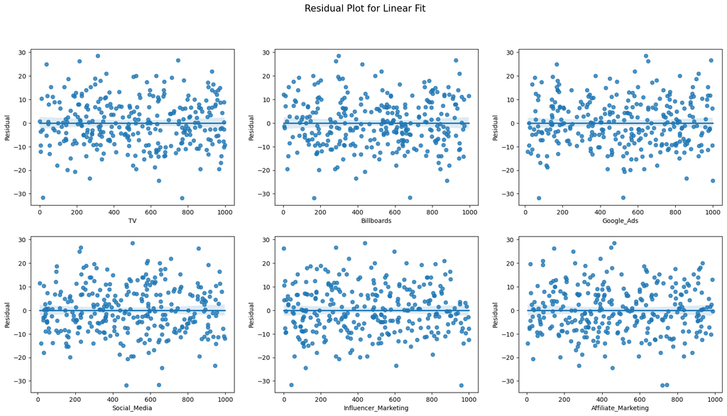

```python
import matplotlib.pyplot as plt
import seaborn as sns

fig, axs = plt.subplots(nrows = 2, ncols = 3, figsize = (20, 10))
for n, col in enumerate(data[X.columns]):
    i, j = n//3, n%3
    sns.regplot(x = data[col], y = data["Residual"], ax =  axs[i][j])

plt.suptitle('Residual Plot for Linear Fit', fontsize = 15)
plt.show()
```

### 2.오차항들간의 상관성은 있는지 없는지 (계열상관성)

1. 시각화 하여 확인

https://blog.naver.com/yonxman/220960992282

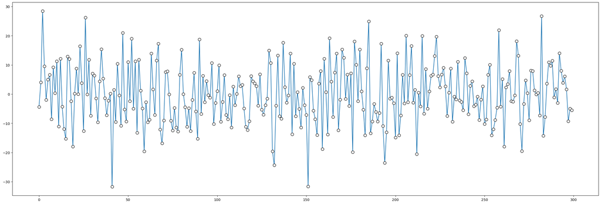

```python
plt.figure(figsize = (30, 10))
plt.plot(data.index, data['Residual'], marker ='o', markersize = 8, mfc = 'white', mec = 'black')
```

오차항들 간의 상관성이 없어 보임

2. 더빈왓슨검정법

```python
import statsmodels.formula.api as smf
lm = smf.ols(formula = 'Product_Sold ~ TV+Billboards+Google_Ads+Social_Media+Influencer_Marketing+Affiliate_Marketing', data = data).fit()
lm.summary()
```

OLS Regression Results

| Dep. Variable: | Product_Sold | R-squared: | 1.000 |
| --- | --- | --- | --- |
| Model: | OLS | Adj. R-squared: | 1.000 |
| Method: | Least Squares | F-statistic: | 1.347e+06 |
| Date: | Thu, 09 May 2024 | Prob (F-statistic): | 0.00 |
| Time: | 13:02:43 | Log-Likelihood: | -1123.6 |
| No. Observations: | 300 | AIC: | 2261. |
| Df Residuals: | 293 | BIC: | 2287. |
| Df Model: | 6 |  |  |
| Covariance Type: | nonrobust |  |  |

|  | coef | std err | t | P>\|t\| | [0.025 | 0.975] |
| --- | --- | --- | --- | --- | --- | --- |
| Intercept | 0.0887 | 2.723 | 0.033 | 0.974 | -5.270 | 5.447 |
| TV | 2.0011 | 0.002 | 956.708 | 0.000 | 1.997 | 2.005 |
| Billboards | 2.9980 | 0.002 | 1375.489 | 0.000 | 2.994 | 3.002 |
| Google_Ads | 1.4997 | 0.002 | 704.836 | 0.000 | 1.496 | 1.504 |
| Social_Media | 2.5000 | 0.002 | 1138.719 | 0.000 | 2.496 | 2.504 |
| Influencer_Marketing | 1.1998 | 0.002 | 574.871 | 0.000 | 1.196 | 1.204 |
| Affiliate_Marketing | 3.9989 | 0.002 | 1827.081 | 0.000 | 3.995 | 4.003 |

| Omnibus: | 0.258 | Durbin-Watson: | 2.081 |
| --- | --- | --- | --- |
| Prob(Omnibus): | 0.879 | Jarque-Bera (JB): | 0.170 |
| Skew: | 0.057 | Prob(JB): | 0.918 |
| Kurtosis: | 3.028 | Cond. No. | 5.67e+03 |

Notes:  
[1] Standard Errors assume that the covariance matrix of the errors is correctly specified.  
[2] The condition number is large, 5.67e+03. This might indicate that there are  
strong multicollinearity or other numerical problems.

Durbin Watson 검정통계량이 2 주변이라면 자기 상관이 존재하지 않음 https://m.blog.naver.com/yolwooju/221915408383

2보다 큰값이면 음의 자기 상관성

2보다 작은값이면 양의 자기상관성을 가진다고 판단함.

--> Durbin Watson 검정통계량이 2.081 이므로 자기상관이 거의 존재하지 않다고 봄

### 3.오차항의 기댓값은 0 -> 만족

```python
lm.resid.describe()
```

```
count   300.00
mean     -0.00
std      10.26
min     -31.75
25%      -7.25
50%      -0.44
75%       6.87
max      28.44
dtype: float64
```

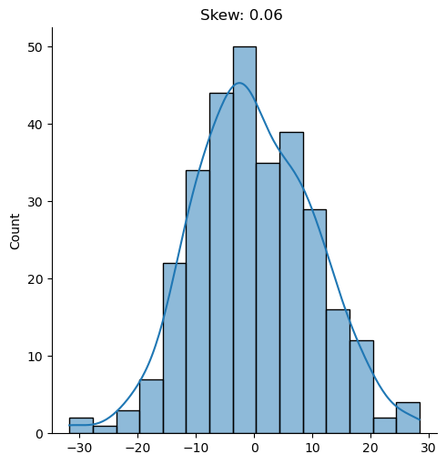

```python
sns.displot(lm.resid, kde = True)
plt.title(f"Skew: {round(lm.resid.skew(), 2)} ")
```

### 4.오차항의 분산은 모든 관찰치에서 일정할 것 (이분산성)

-> 만약 불만족 한다면? 종속변수(반응변수)를 Transform

-> weighted regression을 사용

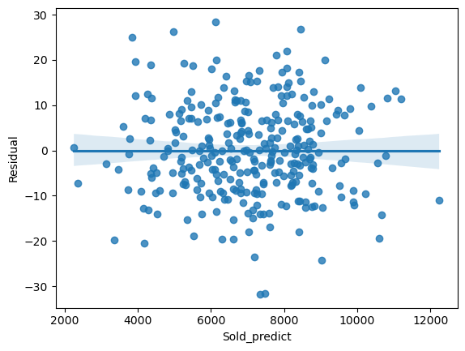

```python
sns.regplot(x = data["Sold_predict"], y = data["Residual"])
```

2. White의 이분산 검정법

https://www.statology.org/white-test-in-python/

```python
from statsmodels.stats.diagnostic import het_white

white_test = het_white(lm.resid, lm.model.exog)
```

```python
lm.model.exog # 관측치 값
```

```
array([[  1.  , 281.42, 538.8 , ..., 349.3 , 242.77, 910.1 ],
       [  1.  , 702.97, 296.53, ..., 180.55, 781.06, 132.43],
       [  1.  , 313.14, 295.94, ..., 505.71, 438.91, 464.23],
       ...,
       [  1.  , 998.1 , 858.75, ...,  60.61, 174.63, 213.53],
       [  1.  , 322.35, 681.22, ..., 343.65, 534.22, 648.71],
       [  1.  , 476.45, 884.77, ..., 802.3 , 434.82, 401.69]])
```

```python
data.head()
```

[output not shown]

```python
#define labels to use for output of White's test
labels = ['Test Statistic', 'Test Statistic p-value', 'F-Statistic', 'F-Test p-value']
#print results of White's test
test_result = dict(zip(labels, white_test))
print(test_result)
```

```
{'Test Statistic': 27.50937351516273, 'Test Statistic p-value': 0.43658901018407426, 'F-Statistic': 1.0170311914877623, 'F-Test p-value': 0.44541869442067167}
```

Test Statistic $X^2$ = 27.50

p-value = 0.437

$H_a$ : 이분산성이 존재한다. (잔차들은 동등하지 않게 흩어져있다)

p-value가 0.05보다 크므로 귀무가설을 기각할 수 없고 이분산성이 존재하지 않다고 봐야함

### 5. 오차항과 독립변수가 상관관계가 없을 것 (내생성)

```python
for col in data[X.columns]:
    corr = data[[col, 'Residual']].corr()
    print(col, round(corr.loc[col,'Residual'], 2))
```

```
TV 0.0
Billboards 0.0
Google_Ads 0.0
Social_Media -0.0
Influencer_Marketing 0.0
Affiliate_Marketing -0.0
```

상관관계가 거의없음.

### 6.다중공선성 확인

https://aliencoder.tistory.com/17

1. 각 독립변수들간의 상관관계를 확인해본다.
2. 분산팽창요인 (Variance Inflation Factor, VIF)를 구하여 5 또는 10을 넘으면 다중공선성 문제가 있다고 본다.

   연관있는 변수끼리는 VIF가 높다

```python
corr_by_X = data[X.columns].corr()
corr_by_X
```

|  | TV | Billboards | Google_Ads | Social_Media | Influencer_Marketing | Affiliate_Marketing |
| --- | --- | --- | --- | --- | --- | --- |
| TV | 1.00 | -0.03 | 0.03 | -0.04 | 0.01 | 0.09 |
| Billboards | -0.03 | 1.00 | 0.05 | 0.05 | -0.01 | -0.04 |
| Google_Ads | 0.03 | 0.05 | 1.00 | 0.04 | -0.06 | -0.13 |
| Social_Media | -0.04 | 0.05 | 0.04 | 1.00 | -0.04 | -0.02 |
| Influencer_Marketing | 0.01 | -0.01 | -0.06 | -0.04 | 1.00 | -0.05 |
| Affiliate_Marketing | 0.09 | -0.04 | -0.13 | -0.02 | -0.05 | 1.00 |

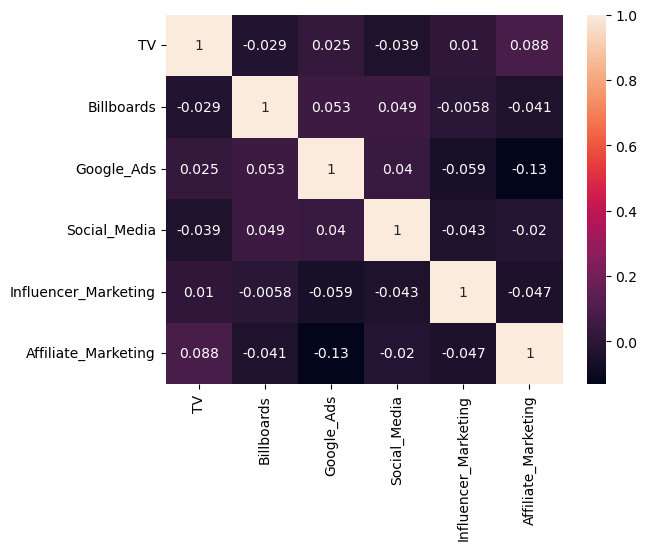

```python
sns.heatmap(corr_by_X, annot = True)
```

```python
# !pip install seaborn --upgrade
```

독립변수간의 상관관계가 거의 없어보인다.

```python
from statsmodels.stats.outliers_influence import variance_inflation_factor
```

```python
def get_VIF(X: pd.DataFrame):
    from statsmodels.stats.outliers_influence import variance_inflation_factor

    vif = pd.DataFrame()
    vif["VIF Factor"] = [variance_inflation_factor(X.values, i) for i in range(X.shape[1])]
    vif["features"] = X.columns
    vif = vif.sort_values("VIF Factor", ascending = False).reset_index(drop = True)
    return vif[["features", "VIF Factor"]]
```

```python
get_VIF(X)
```

|  | features | VIF Factor |
| --- | --- | --- |
| 0 | TV | 3.71 |
| 1 | Billboards | 3.70 |
| 2 | Social_Media | 3.57 |
| 3 | Google_Ads | 3.55 |
| 4 | Affiliate_Marketing | 3.35 |
| 5 | Influencer_Marketing | 3.02 |

VIF 값이 5 이하이므로 다중공선성은 없다

### 7. 이상치 확인

- 이상치: 주어진 설명변수의 값에 대한 반응변수의 값이 보통수준과는 다른 관측치

스튜던트화 잔차의 절대값이 3보다 크면 관측치가 이상치 일 수 있음 https://datascienceschool.net/03%20machine%20learning/05.03%20%EB%A0%88%EB%B2%84%EB%A6%AC%EC%A7%80%EC%99%80%20%EC%95%84%EC%9B%83%EB%9D%BC%EC%9D%B4%EC%96%B4.html

```python
lm.summary()
```

OLS Regression Results

| Dep. Variable: | Product_Sold | R-squared: | 1.000 |
| --- | --- | --- | --- |
| Model: | OLS | Adj. R-squared: | 1.000 |
| Method: | Least Squares | F-statistic: | 1.347e+06 |
| Date: | Thu, 09 May 2024 | Prob (F-statistic): | 0.00 |
| Time: | 12:44:30 | Log-Likelihood: | -1123.6 |
| No. Observations: | 300 | AIC: | 2261. |
| Df Residuals: | 293 | BIC: | 2287. |
| Df Model: | 6 |  |  |
| Covariance Type: | nonrobust |  |  |

|  | coef | std err | t | P>\|t\| | [0.025 | 0.975] |
| --- | --- | --- | --- | --- | --- | --- |
| Intercept | 0.0887 | 2.723 | 0.033 | 0.974 | -5.270 | 5.447 |
| TV | 2.0011 | 0.002 | 956.708 | 0.000 | 1.997 | 2.005 |
| Billboards | 2.9980 | 0.002 | 1375.489 | 0.000 | 2.994 | 3.002 |
| Google_Ads | 1.4997 | 0.002 | 704.836 | 0.000 | 1.496 | 1.504 |
| Social_Media | 2.5000 | 0.002 | 1138.719 | 0.000 | 2.496 | 2.504 |
| Influencer_Marketing | 1.1998 | 0.002 | 574.871 | 0.000 | 1.196 | 1.204 |
| Affiliate_Marketing | 3.9989 | 0.002 | 1827.081 | 0.000 | 3.995 | 4.003 |

| Omnibus: | 0.258 | Durbin-Watson: | 2.081 |
| --- | --- | --- | --- |
| Prob(Omnibus): | 0.879 | Jarque-Bera (JB): | 0.170 |
| Skew: | 0.057 | Prob(JB): | 0.918 |
| Kurtosis: | 3.028 | Cond. No. | 5.67e+03 |

Notes:  
[1] Standard Errors assume that the covariance matrix of the errors is correctly specified.  
[2] The condition number is large, 5.67e+03. This might indicate that there are  
strong multicollinearity or other numerical problems.

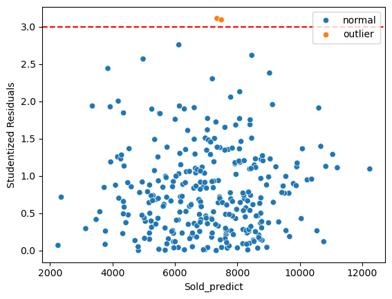

```python
from statsmodels.stats.outliers_influence import OLSInfluence
import numpy as np
data["Studentized Residuals"] = abs(OLSInfluence(lm).resid_studentized)
data["outlier_yn"] = np.where(data["Studentized Residuals"] > 3, 'outlier', 'normal')

sns.scatterplot(x = "Sold_predict", y = "Studentized Residuals", data = data, hue = 'outlier_yn')
plt.axhline(y = 3, color = 'red', linestyle = '--')
plt.legend(loc = 1) # upper right

# del data["Studentized Residuals"]
# del data["outlier_yn"]
```

### 8.레버리지가 높은 관측치 확인

- 레버리지 : 대응하는 x 값이 보통 수준과 다름 -> 최소제곱선에 큰영향을 주는 데이터

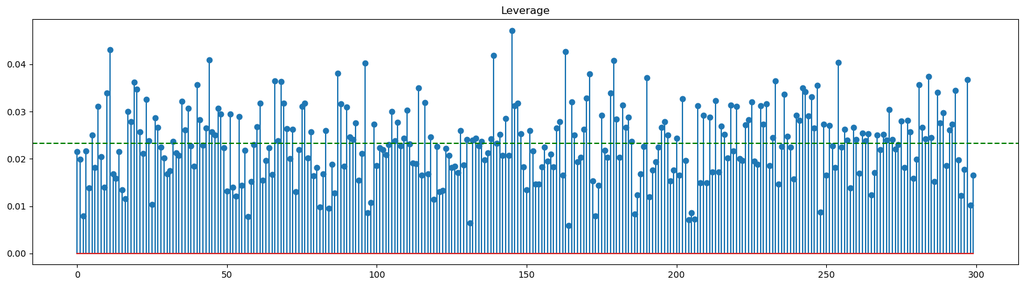

```python
hat = lm.get_influence().hat_matrix_diag

plt.figure(figsize=(20, 5))
plt.stem(hat)
n,p = X.shape[0], X.shape[1]
plt.axhline((p+1)/ n, c="g", ls="--")
plt.title("Leverage")
plt.show()
```

```python
print(round((p+1)/ n, 2), '보다 훨씬 크다면, 높은 레버리지를 가진다고 의심할 수 있음')
```

```
0.02 보다 훨씬 크다면, 높은 레버리지를 가진다고 의심할 수 있음
```

```python
data['Leverage'] = hat
```

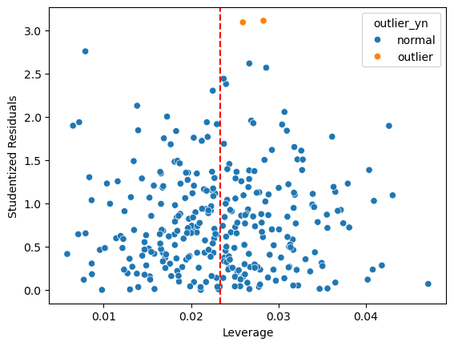

```python
sns.scatterplot(x = 'Leverage', y = 'Studentized Residuals', data = data, hue = 'outlier_yn')
plt.axvline((p+1)/n, color = 'red', linestyle = '--')
```

최소제곱적합에 큰 영향을 주는 데이터가 반 이상 레버리지가 큰 데이터들임

변수 하나씩 선형회귀모델에 적합했을 때, R-sqaured 값 비교

```python
import statsmodels.formula.api as smf

for col in X.columns:
    lm_tmp = smf.ols(formula = f'Product_Sold ~ {col}', data = data).fit()
    print(col, round(lm_tmp.rsquared,2))
```

```
TV 0.14
Billboards 0.23
Google_Ads 0.04
Social_Media 0.16
Influencer_Marketing 0.02
Affiliate_Marketing 0.37
```

제휴마케팅이 분산을 가장 많이 설명함

```python
lm_dict = {col : smf.ols(formula = f'Product_Sold ~ {col}', data = data).fit() for col in X.columns}
```

각 단순선형회귀의 잔차 평균이 0인지 확인

```python
for col in X.columns:
    print(col, round((lm_dict[col].resid).describe()['mean'], 2))
```

```
TV 0.0
Billboards 0.0
Google_Ads 0.0
Social_Media -0.0
Influencer_Marketing -0.0
Affiliate_Marketing 0.0
```

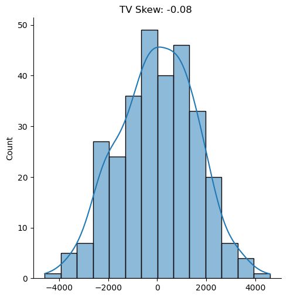

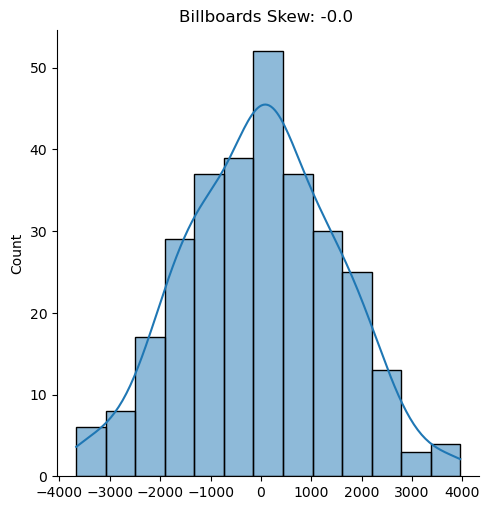

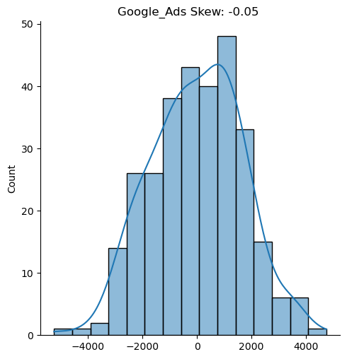

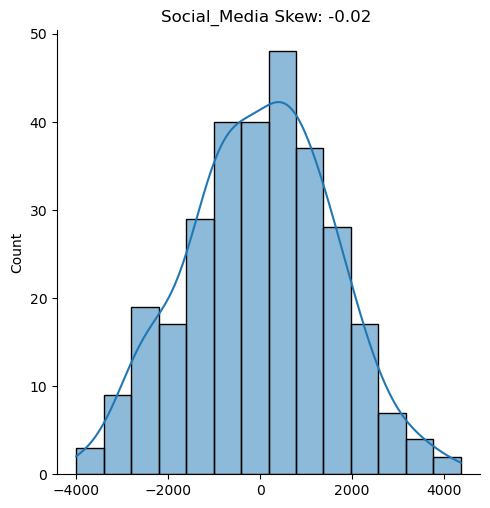

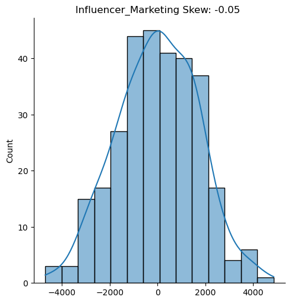

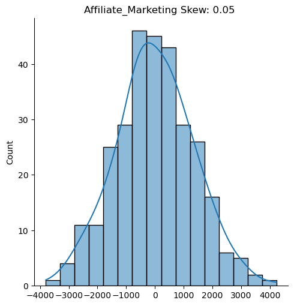

```python
for col in X.columns:
    sns.displot(lm_dict[col].resid, kde = True)
    plt.title(f"{col} Skew: {round(lm_dict[col].resid.skew(), 2)} ")
```

잔차는 정규분포를 따름

## 전진선택법을 통한 변수선택

```python
from mlxtend.feature_selection import SequentialFeatureSelector as sfs

clf = LinearRegression()

# Build step forward feature selection
sfs1 = sfs(clf,k_features = len(X.columns),forward=True,floating=False, scoring='r2',cv=5)

# Perform SFFS
sfs1 = sfs1.fit(X, y)
```

```python
# !pip install mlxtend
```

```python
sfs1.subsets_
```

```
{1: {'feature_idx': (5,),
  'cv_scores': array([0.25741663, 0.43498281, 0.2433973 , 0.47921549, 0.39957291]),
  'avg_score': 0.3629170284881732,
  'feature_names': ('Affiliate_Marketing',)},
 2: {'feature_idx': (1, 5),
  'cv_scores': array([0.52434498, 0.68507189, 0.57668981, 0.60757078, 0.6854429 ]),
  'avg_score': 0.6158240707453804,
  'feature_names': ('Billboards', 'Affiliate_Marketing')},
 3: {'feature_idx': (1, 3, 5),
  'cv_scores': array([0.72780598, 0.78346658, 0.7780815 , 0.7358237 , 0.82797891]),
  'avg_score': 0.7706313344876781,
  'feature_names': ('Billboards', 'Social_Media', 'Affiliate_Marketing')},
 4: {'feature_idx': (0, 1, 3, 5),
  'cv_scores': array([0.87149561, 0.88467551, 0.90570006, 0.90576646, 0.92633109]),
  'avg_score': 0.8987937463433641,
  'feature_names': ('TV',
   'Billboards',
   'Social_Media',
   'Affiliate_Marketing')},
 5: {'feature_idx': (0, 1, 2, 3, 5),
  'cv_scores': array([0.94861435, 0.96040431, 0.94832765, 0.9577421 , 0.964382  ]),
  'avg_score': 0.9558940809692344,
  'feature_names': ('TV',
   'Billboards',
   'Google_Ads',
   'Social_Media',
   'Affiliate_Marketing')},
 6: {'feature_idx': (0, 1, 2, 3, 4, 5),
  'cv_scores': array([0.99994857, 0.99997121, 0.99995535, 0.99994838, 0.99997497]),
  'avg_score': 0.9999596955535814,
  'feature_names': ('TV',
   'Billboards',
   'Google_Ads',
   'Social_Media',
   'Influencer_Marketing',
   'Affiliate_Marketing')}}
```

95% 분산에 대한 설명력을 가지는 TV / Billboards / Google Ads / Social Media / Affiliate_Marketing 을 적합하면 오차항이 정규분포를 따를까?

```python
import statsmodels.formula.api as smf
lm5 = smf.ols(formula = 'Product_Sold ~ TV+Billboards+Google_Ads+Social_Media+Affiliate_Marketing', data = data).fit()
lm5.summary()
```

OLS Regression Results

| Dep. Variable: | Product_Sold | R-squared: | 0.959 |
| --- | --- | --- | --- |
| Model: | OLS | Adj. R-squared: | 0.958 |
| Method: | Least Squares | F-statistic: | 1378. |
| Date: | Thu, 09 May 2024 | Prob (F-statistic): | 1.14e-201 |
| Time: | 12:51:20 | Log-Likelihood: | -2177.9 |
| No. Observations: | 300 | AIC: | 4368. |
| Df Residuals: | 294 | BIC: | 4390. |
| Df Model: | 5 |  |  |
| Covariance Type: | nonrobust |  |  |

|  | coef | std err | t | P>\|t\| | [0.025 | 0.975] |
| --- | --- | --- | --- | --- | --- | --- |
| Intercept | 651.6564 | 83.031 | 7.848 | 0.000 | 488.246 | 815.066 |
| TV | 2.0192 | 0.070 | 28.783 | 0.000 | 1.881 | 2.157 |
| Billboards | 2.9951 | 0.073 | 40.968 | 0.000 | 2.851 | 3.139 |
| Google_Ads | 1.4203 | 0.071 | 19.943 | 0.000 | 1.280 | 1.561 |
| Social_Media | 2.4489 | 0.074 | 33.282 | 0.000 | 2.304 | 2.594 |
| Affiliate_Marketing | 3.9268 | 0.073 | 53.577 | 0.000 | 3.783 | 4.071 |

| Omnibus: | 148.415 | Durbin-Watson: | 1.987 |
| --- | --- | --- | --- |
| Prob(Omnibus): | 0.000 | Jarque-Bera (JB): | 18.073 |
| Skew: | 0.101 | Prob(JB): | 0.000119 |
| Kurtosis: | 1.815 | Cond. No. | 4.78e+03 |

Notes:  
[1] Standard Errors assume that the covariance matrix of the errors is correctly specified.  
[2] The condition number is large, 4.78e+03. This might indicate that there are  
strong multicollinearity or other numerical problems.

```python
round(lm5.resid.mean(),2)
```

```
-0.0
```

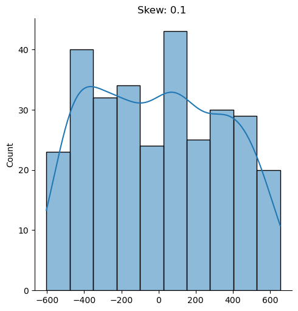

```python
sns.displot(lm5.resid, kde = True)
plt.title(f"Skew: {round(lm5.resid.skew(), 2)} ")
```

이상치만를 제거하고 다중선형회귀 재적합

```python
import warnings
warnings.filterwarnings('ignore')
```

```python
data_prep1 = data[(data['outlier_yn'] == 'normal')]

X1 = data_prep1[['TV', 'Billboards', 'Google_Ads', 'Social_Media','Influencer_Marketing', 'Affiliate_Marketing']]
y1 = data_prep1['Product_Sold']

from sklearn.linear_model import LinearRegression
mlr_model1 = LinearRegression()
mlr_model1.fit(X1,  y1)

data_prep1['Sold_predict'] = mlr_model1.predict(X1)
data_prep1['Residual'] = (data_prep1['Product_Sold'] - data_prep1['Sold_predict'])
print('MSE: ', np.mean(data_prep1['Residual']**2)) # MSE
```

```
MSE:  98.6953741465248
```

```python
(104-98)/104
```

```
0.057692307692307696
```

MSE가 104 에서 98로 5.7% 감소

```python
print('R^2: ', mlr_model1.score(X1,y1))
```

```
R^2:  0.9999660976269081
```

```python
b0 = round(mlr_model1.intercept_, 2)
b1 = round(mlr_model1.coef_[0], 2)
b2 = round(mlr_model1.coef_[1], 2)
b3 = round(mlr_model1.coef_[2], 2)
b4 = round(mlr_model1.coef_[3], 2)
b5 = round(mlr_model1.coef_[4], 2)
b6 = round(mlr_model1.coef_[5], 2)

print(f'회귀식 Product_Sold ~ {b0} + {b1} TV + {b2} Billboards + {b3} Google_Ads + {b4} Social_Media + {b5} Influencer_Marketing + {b6} Affiliate_Marketing')
```

```
회귀식 Product_Sold ~ 0.35 + 2.0 TV + 3.0 Billboards + 1.5 Google_Ads + 2.5 Social_Media + 1.2 Influencer_Marketing + 4.0 Affiliate_Marketing
```

회귀식의 intercept만 0.09 -> 0.35 로 증가

```python
data
```

|  | TV | Billboards | Google_Ads | Social_Media | Influencer_Marketing | Affiliate_Marketing | Product_Sold | Sold_predict | Residual | Studentized Residuals | outlier_yn | Leverage |
| --- | --- | --- | --- | --- | --- | --- | --- | --- | --- | --- | --- | --- |
| 0 | 281.42 | 538.80 | 123.94 | 349.30 | 242.77 | 910.10 | 7164.00 | 7168.42 | -4.42 | 0.43 | normal | 0.02 |
| 1 | 702.97 | 296.53 | 558.13 | 180.55 | 781.06 | 132.43 | 5055.00 | 5050.98 | 4.02 | 0.39 | normal | 0.02 |
| 2 | 313.14 | 295.94 | 642.96 | 505.71 | 438.91 | 464.23 | 6154.00 | 6125.56 | 28.44 | 2.76 | normal | 0.01 |
| 3 | 898.52 | 61.27 | 548.73 | 240.93 | 278.96 | 432.27 | 5480.00 | 5470.42 | 9.58 | 0.93 | normal | 0.02 |
| 4 | 766.52 | 550.72 | 651.91 | 666.33 | 396.33 | 841.93 | 9669.00 | 9670.94 | -1.94 | 0.19 | normal | 0.01 |
| ... | ... | ... | ... | ... | ... | ... | ... | ... | ... | ... | ... | ... |
| 295 | 770.05 | 501.36 | 694.60 | 172.26 | 572.26 | 410.56 | 6851.00 | 6844.93 | 6.07 | 0.59 | normal | 0.01 |
| 296 | 512.38 | 250.83 | 373.78 | 366.95 | 987.14 | 509.03 | 6477.00 | 6475.35 | 1.65 | 0.16 | normal | 0.02 |
| 297 | 998.10 | 858.75 | 781.06 | 60.61 | 174.63 | 213.53 | 6949.00 | 6958.30 | -9.30 | 0.91 | normal | 0.04 |
| 298 | 322.35 | 681.22 | 640.29 | 343.65 | 534.22 | 648.71 | 7737.00 | 7741.99 | -4.99 | 0.48 | normal | 0.01 |
| 299 | 476.45 | 884.77 | 301.79 | 802.30 | 434.82 | 401.69 | 8187.00 | 8192.51 | -5.51 | 0.54 | normal | 0.02 |

300 rows × 12 columns

# 결론

다중 선형회귀식

#### Product_Sold ~ 0.35 + 2.0 TV + 3.0 Billboards + 1.5 Google_Ads + 2.5 Social_Media + 1.2 Influencer_Marketing + 4.0 Affiliate_Marketing

- 상품매출판매액은 **제휴마케팅 예산**에 민감하게 반응하며, **인플루언서 마케팅 비용**에 가장 적게 영향을 받는다.
- 상품매출판매액은 아무 마케팅 예산을 사용하지 않을때 0.35 단위 정도 판매액에 영향을 준다.
1. 반응변수와 설명변수 간의 비선형관계인지 / 선형관계인지 (선형성) -> 잔차그래프에서 인지할만한 패턴이 존재하지 않는다
2. 오차항들간의 상관성은 있는지 없는지 (계열상관성))-> 오차항들 간의 상관성이 없어 보임, Durbin Watson 검정통계량이 2.081 이므로 자기상관이 거의 존재하지 않다고봄
3. 오차항의 기댓값은 0 정규분포를 따름
4. 오차항의 분산은 모든 관찰치에서 일정할 것 (등분산성) (이분산성X) -> 이분산성이 존재하지 않다고 봐야함
5. 오차항과 독립변수가 상관관계가 없을 것 (내생성) -> 상관관계가 거의없음.
6. 다중공선성 확인 (다중회귀모형) -> 독립변수간의 상관관계가 거의 없어보인다. VIF 값이 5 이하이므로 다중공선성은 없다
7. **이상치 확인 및 제거** -> 스튜던트화 잔차의 절대값이 3보다 큰, 2개의 이상치가 존재한다.
8. **레버리지가 높은 관측치 확인** -> 반은 레버리지가 큰 데이터들임, 최소제곱적합에 큰 영향을 주는 데이터들이 존재한다.

# 가설 검정

## Q. 광고 예산과 매출액 사이에 상관관계가 있는가?

> H0: $b_1$ = ... = $b_6$ = 0

> Ha: 하나의 $b_j$ 가 0이 아니다.

```python
import statsmodels.formula.api as smf
lm_prep = smf.ols(formula = 'Product_Sold ~ TV+Billboards+Google_Ads+Social_Media+Influencer_Marketing+Affiliate_Marketing', data = data_prep1).fit()
lm_prep.summary()
```

OLS Regression Results

| Dep. Variable: | Product_Sold | R-squared: | 1.000 |
| --- | --- | --- | --- |
| Model: | OLS | Adj. R-squared: | 1.000 |
| Method: | Least Squares | F-statistic: | 1.431e+06 |
| Date: | Thu, 09 May 2024 | Prob (F-statistic): | 0.00 |
| Time: | 13:38:58 | Log-Likelihood: | -1107.1 |
| No. Observations: | 298 | AIC: | 2228. |
| Df Residuals: | 291 | BIC: | 2254. |
| Df Model: | 6 |  |  |
| Covariance Type: | nonrobust |  |  |

|  | coef | std err | t | P>\|t\| | [0.025 | 0.975] |
| --- | --- | --- | --- | --- | --- | --- |
| Intercept | 0.3505 | 2.643 | 0.133 | 0.895 | -4.852 | 5.553 |
| TV | 2.0007 | 0.002 | 979.398 | 0.000 | 1.997 | 2.005 |
| Billboards | 2.9978 | 0.002 | 1413.649 | 0.000 | 2.994 | 3.002 |
| Google_Ads | 1.4993 | 0.002 | 724.041 | 0.000 | 1.495 | 1.503 |
| Social_Media | 2.5002 | 0.002 | 1173.268 | 0.000 | 2.496 | 2.504 |
| Influencer_Marketing | 1.2000 | 0.002 | 587.841 | 0.000 | 1.196 | 1.204 |
| Affiliate_Marketing | 3.9996 | 0.002 | 1878.503 | 0.000 | 3.995 | 4.004 |

| Omnibus: | 3.395 | Durbin-Watson: | 2.089 |
| --- | --- | --- | --- |
| Prob(Omnibus): | 0.183 | Jarque-Bera (JB): | 3.376 |
| Skew: | 0.222 | Prob(JB): | 0.185 |
| Kurtosis: | 2.726 | Cond. No. | 5.65e+03 |

Notes:  
[1] Standard Errors assume that the covariance matrix of the errors is correctly specified.  
[2] The condition number is large, 5.65e+03. This might indicate that there are  
strong multicollinearity or other numerical problems.

```python
lm_prep.fvalue
```

```
1430529.8217169289
```

```python
lm_prep.f_pvalue
```

```
0.0
```

f_pvalue 값이 0.05보다 작으므로, 귀무가설을 기각하고, 광고와 매출액 사이의 상관관계가 존재한다고 볼 수있다.

## Q. 광고 예산과 매출액 사이에 얼마나 강한 상관관계가 있는가?

```python
print("RSE (Residual Standard Error of the model)", lm_prep.resid.std(ddof = X1.shape[1]))
```

```
RSE (Residual Standard Error of the model) 10.036102893380612
```

```python
print("R-sqaure", round(lm_prep.rsquared*100,3))
```

```
R-sqaure 99.997
```

```python
print("반응변수의 평균값:", y1.mean())
```

```
반응변수의 평균값: 7029.147651006711
```

```python
print("오차:" ,10.03 / 7029.14  * 100  , "%")
```

```
오차: 0.14269170908532194 %
```

R-sqaure 가 99.99% 으로 설명변수에 의해 반응변수의 99%가 설명이되며, 오차가 0.14% 로 매우 낮기 때문에 강한 상관관계가 있다고 볼 수 있다.

## Q. 어느 매체가 판매에 기여하는가?

```python
lm_prep.summary()
```

OLS Regression Results

| Dep. Variable: | Product_Sold | R-squared: | 1.000 |
| --- | --- | --- | --- |
| Model: | OLS | Adj. R-squared: | 1.000 |
| Method: | Least Squares | F-statistic: | 1.431e+06 |
| Date: | Thu, 09 May 2024 | Prob (F-statistic): | 0.00 |
| Time: | 13:59:30 | Log-Likelihood: | -1107.1 |
| No. Observations: | 298 | AIC: | 2228. |
| Df Residuals: | 291 | BIC: | 2254. |
| Df Model: | 6 |  |  |
| Covariance Type: | nonrobust |  |  |

|  | coef | std err | t | P>\|t\| | [0.025 | 0.975] |
| --- | --- | --- | --- | --- | --- | --- |
| Intercept | 0.3505 | 2.643 | 0.133 | 0.895 | -4.852 | 5.553 |
| TV | 2.0007 | 0.002 | 979.398 | 0.000 | 1.997 | 2.005 |
| Billboards | 2.9978 | 0.002 | 1413.649 | 0.000 | 2.994 | 3.002 |
| Google_Ads | 1.4993 | 0.002 | 724.041 | 0.000 | 1.495 | 1.503 |
| Social_Media | 2.5002 | 0.002 | 1173.268 | 0.000 | 2.496 | 2.504 |
| Influencer_Marketing | 1.2000 | 0.002 | 587.841 | 0.000 | 1.196 | 1.204 |
| Affiliate_Marketing | 3.9996 | 0.002 | 1878.503 | 0.000 | 3.995 | 4.004 |

| Omnibus: | 3.395 | Durbin-Watson: | 2.089 |
| --- | --- | --- | --- |
| Prob(Omnibus): | 0.183 | Jarque-Bera (JB): | 3.376 |
| Skew: | 0.222 | Prob(JB): | 0.185 |
| Kurtosis: | 2.726 | Cond. No. | 5.65e+03 |

Notes:  
[1] Standard Errors assume that the covariance matrix of the errors is correctly specified.  
[2] The condition number is large, 5.65e+03. This might indicate that there are  
strong multicollinearity or other numerical problems.

p-value가 0으로 모두 낮아서, 모든 매체가 판매에 기여하며, 계수가 가장 높은 제휴마케팅(Affiliate_Marketing) 이 가장 큰 기여를 했고, 인플루언서 마케팅이 가장 낮은 기여를 했다.

## Q 판매에 대한 각 매체의 효과는 얼마나 되는가?

모든 매체들의 신뢰구간이 0을 포함하지 않다. 제휴마케팅, 빌보드, 소셜미디어 순으로 판매에 기여했다.

## Q 광고 매체 사이에 시너지가 있는가?

두 변수를 곱한 설명변수 없이도 99.99%를 설명하기 때문에 매체간 상호작용효과(시너지 효과)는 없다고 할 수있다.